# Credit Risk

### Modelling

#### types of models:

##### 1.

**note: since reference is “good”, we are predicting “bad” risk**

```r
# Logistic regression
train_set$Risk = relevel(as.factor(train_set$Risk), ref="good")
log_model = glm(Risk ~ Age + Sex + Job + Housing + Saving_accounts +
                  Checking_accounts + Credit_amount + Duration + Purpose,
                data=train_set, family="binomial")
summary(log_model)
```

```
##
## Call:
## glm(formula = Risk ~ Age + Sex + Job + Housing + Saving_accounts +
##     Checking_accounts + Credit_amount + Duration + Purpose, family = "binomial",
##     data = train_set)
##
## Coefficients:
##                              Estimate Std. Error z value Pr(>|z|)
## (Intercept)                 8.904e-01  6.915e-01   1.288 0.197849
## Age                        -1.858e-02  8.599e-03  -2.161 0.030730 *
## Sexmale                    -4.109e-01  1.931e-01  -2.128 0.033350 *
## Job                         1.600e-02  1.415e-01   0.113 0.909999
## Housingown                 -6.116e-01  3.034e-01  -2.016 0.043805 *
## Housingrent                -2.827e-01  3.578e-01  -0.790 0.429377
## Saving_accountsmoderate    -1.501e-01  2.951e-01  -0.509 0.611022
## Saving_accountsnone        -8.719e-01  2.662e-01  -3.275 0.001057 **
## Saving_accountsquite rich  -3.696e-01  4.226e-01  -0.874 0.381899
## Saving_accountsrich        -1.108e+00  5.694e-01  -1.946 0.051638 .
## Checking_accountsmoderate  -4.536e-01  2.226e-01  -2.038 0.041574 *
## Checking_accountsnone      -1.804e+00  2.398e-01  -7.524 5.29e-14 ***
## Checking_accountsrich      -1.071e+00  3.696e-01  -2.898 0.003753 **
## Credit_amount               2.687e-05  4.177e-05   0.643 0.519962
## Duration                    3.335e-02  9.400e-03   3.548 0.000389 ***
## Purposecar                 -1.405e-01  3.245e-01  -0.433 0.664972
## Purposedomestic appliances  3.191e-01  7.733e-01   0.413 0.679819
## Purposeeducation            4.691e-02  4.667e-01   0.101 0.919934
## Purposefurniture/equipment -1.625e-01  3.514e-01  -0.462 0.643810
## Purposeradio/TV            -5.654e-01  3.326e-01  -1.700 0.089131 .
## Purposerepairs              4.222e-02  6.340e-01   0.067 0.946907
## Purposevacation/others     -1.315e+00  8.209e-01  -1.602 0.109217
## ---
## Signif. codes:  0 '***' 0.001 '**' 0.01 '*' 0.05 '.' 0.1 ' ' 1
##
## (Dispersion parameter for binomial family taken to be 1)
##
##     Null deviance: 965.23  on 799  degrees of freedom
## Residual deviance: 790.61  on 778  degrees of freedom
## AIC: 834.61
##
## Number of Fisher Scoring iterations: 5
```

```r
# rerun model with only significant predictors
log_mod2 = glm(Risk ~ Age + Sex + Housing + Saving_accounts +
                  Checking_accounts + Duration ,
                data=train_set, family="binomial")
summary(log_mod2)
```

```
##
## Call:
## glm(formula = Risk ~ Age + Sex + Housing + Saving_accounts +
##     Checking_accounts + Duration, family = "binomial", data = train_set)
##
## Coefficients:
##                            Estimate Std. Error z value Pr(>|z|)
## (Intercept)                0.730069   0.524171   1.393  0.16368
## Age                       -0.018189   0.008443  -2.154  0.03122 *
## Sexmale                   -0.397203   0.189805  -2.093  0.03638 *
## Housingown                -0.654948   0.290102  -2.258  0.02397 *
## Housingrent               -0.283979   0.347990  -0.816  0.41447
## Saving_accountsmoderate   -0.140757   0.291694  -0.483  0.62942
## Saving_accountsnone       -0.828216   0.261292  -3.170  0.00153 **
## Saving_accountsquite rich -0.401733   0.417955  -0.961  0.33646
## Saving_accountsrich       -1.073296   0.570009  -1.883  0.05971 .
## Checking_accountsmoderate -0.478762   0.214907  -2.228  0.02590 *
## Checking_accountsnone     -1.803230   0.233751  -7.714 1.22e-14 ***
## Checking_accountsrich     -1.117910   0.365177  -3.061  0.00220 **
## Duration                   0.036001   0.007311   4.924 8.48e-07 ***
## ---
## Signif. codes:  0 '***' 0.001 '**' 0.01 '*' 0.05 '.' 0.1 ' ' 1
##
## (Dispersion parameter for binomial family taken to be 1)
##
##     Null deviance: 965.23  on 799  degrees of freedom
## Residual deviance: 799.52  on 787  degrees of freedom
## AIC: 825.52
##
## Number of Fisher Scoring iterations: 5
```

```r
log_pred = predict(log_mod2, newdata = test_set, type = "response")
log_prob = ifelse(log_pred < 0.314, "good", "bad")
log_conf_mat= table(predict_status=log_prob,
                    true_status=test_set$Risk)
log_conf_mat
```

```
##               true_status
## predict_status bad good
##           bad   50   49
##           good  17   84
```

#### 2.

```r
# LDA model
lda_mod = lda(Risk ~ Age + Sex + Job + Housing + Saving_accounts +
                  Checking_accounts + Credit_amount + Duration + Purpose,
              data=train_set)
lda_mod
```

```
## Call:
## lda(Risk ~ Age + Sex + Job + Housing + Saving_accounts + Checking_accounts +
##     Credit_amount + Duration + Purpose, data = train_set)
##
## Prior probabilities of groups:
##    good     bad
## 0.70875 0.29125
##
## Group means:
##           Age   Sexmale      Job Housingown Housingrent Saving_accountsmoderate
## good 36.41799 0.7160494 1.890653  0.7583774   0.1587302              0.09876543
## bad  33.57082 0.6223176 1.931330  0.6094421   0.2403433              0.10729614
##      Saving_accountsnone Saving_accountsquite rich Saving_accountsrich
## good           0.2310406                0.07231041          0.04938272
## bad            0.1072961                0.03862661          0.01716738
##      Checking_accountsmoderate Checking_accountsnone Checking_accountsrich
## good                 0.2363316             0.4955908            0.08289242
## bad                  0.3304721             0.1630901            0.05150215
##      Credit_amount Duration Purposecar Purposedomestic appliances
## good      2968.101 19.11111  0.3280423                 0.01058201
## bad       3849.854 24.81116  0.3562232                 0.01716738
##      Purposeeducation Purposefurniture/equipment Purposeradio/TV Purposerepairs
## good       0.05467372                  0.1640212       0.3209877     0.02292769
## bad        0.06866953                  0.2103004       0.2017167     0.02145923
##      Purposevacation/others
## good             0.01234568
## bad              0.01287554
##
## Coefficients of linear discriminants:
##                                      LD1
## Age                        -1.451349e-02
## Sexmale                    -3.684389e-01
## Job                         5.930904e-03
## Housingown                 -6.272024e-01
## Housingrent                -2.700909e-01
## Saving_accountsmoderate    -1.116562e-01
## Saving_accountsnone        -7.069238e-01
## Saving_accountsquite rich  -3.162720e-01
## Saving_accountsrich        -8.789056e-01
## Checking_accountsmoderate  -5.931377e-01
## Checking_accountsnone      -1.737996e+00
## Checking_accountsrich      -1.236694e+00
## Credit_amount               2.674819e-05
## Duration                    3.414709e-02
## Purposecar                 -1.281444e-01
## Purposedomestic appliances  3.769540e-01
## Purposeeducation            8.239708e-02
## Purposefurniture/equipment -1.274392e-01
## Purposeradio/TV            -4.651657e-01
## Purposerepairs              3.406656e-03
## Purposevacation/others     -1.329461e+00
```

- prior probabilities: $\hat{\pi}_{good} = 0.70875$ , $\hat{\pi}_{bad} = 0.29125$

```r
lda_pred_class = predict(lda_mod, newdata=test_set)$class
lda_conf_mat = table(predict_status= lda_pred_class,
                     true_status= test_set$Risk)
lda_conf_mat
```

```
##               true_status
## predict_status bad good
##           good  35  110
##           bad   32   23
```

#### 3.

```r
# random forest
p=ncol(train_set) - 1
set.seed(4)
forest_model = randomForest(Risk ~., data=train_set,
                            mtry=round(sqrt(p)), importance=T)
```

```r
rf.pred = predict(forest_model, test_set, type="class")
forest_conf_mat = table(pred=rf.pred,
                     true= test_set$Risk)
forest_conf_mat
```

```
##       true
## pred   bad good
##   good  37  115
##   bad   30   18
```

##### 4.

```r
# boosting model
bag.df = credit %>%
  mutate(Sex = factor(Sex),
         Housing= factor(Housing),
         Saving_accounts = factor(Saving_accounts),
         Checking_accounts = factor(Checking_accounts),
         Purpose = factor(Purpose),
         Risk= factor(ifelse(Risk=="good", 1, 0)))
bag.df = bag.df %>%
  dplyr::select(-id)

# create training set and testing set
n = nrow(bag.df)

set.seed(1)
Z = sample(n, size=n*0.8)

bag.train = bag.df[Z,]
bag.test=bag.df[-Z,]
```

```r
# bagging model
bag_fit = randomForest(Risk ~ ., data=bag.train,
                       mtry=p, importance=TRUE)
bag_fit
```

```
##
## Call:
##  randomForest(formula = Risk ~ ., data = bag.train, mtry = p,      importance = TRUE)
##                Type of random forest: classification
##                      Number of trees: 500
## No. of variables tried at each split: 9
##
##         OOB estimate of  error rate: 26%
## Confusion matrix:
##    0   1 class.error
## 0 98 135   0.5793991
## 1 73 494   0.1287478
```

```r
importance(bag_fit, type=2)
```

```
##                   MeanDecreaseGini
## Age                      58.977145
## Sex                       6.708657
## Job                      15.382689
## Housing                  11.995564
## Saving_accounts          23.524370
## Checking_accounts        45.305604
## Credit_amount            89.751259
## Duration                 47.304215
## Purpose                  30.330862
```

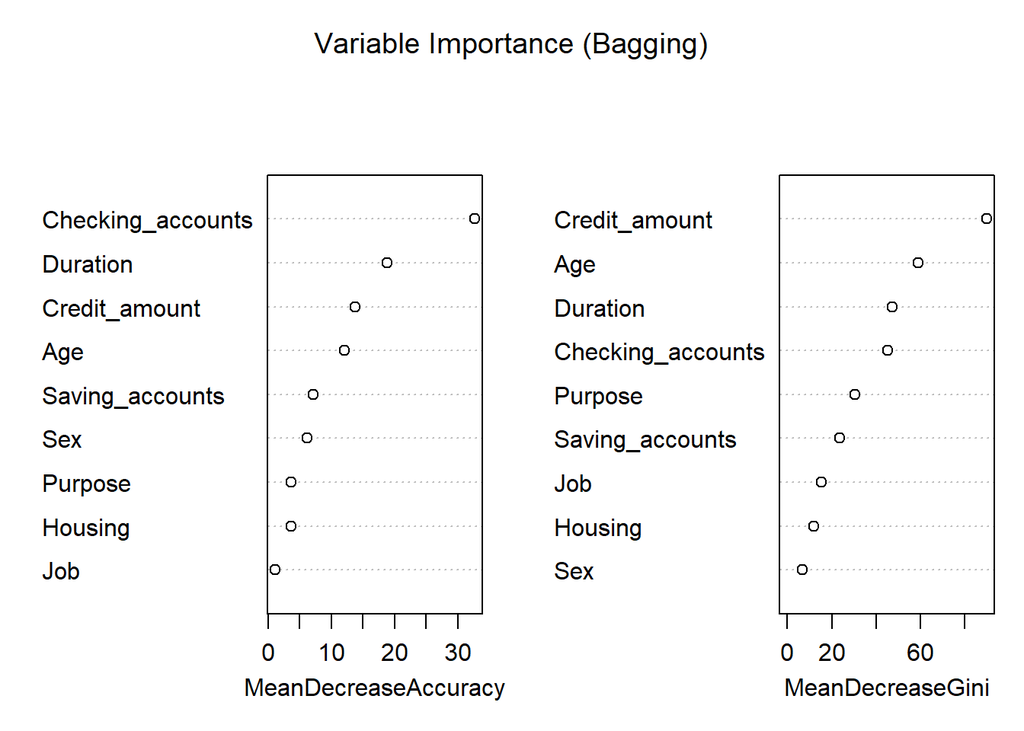

```r
varImpPlot(bag_fit, main="Variable Importance (Bagging)")
```

```r
yhat.test_bag = predict(bag_fit, bag.test, type="class")
bag_conf_mat= table(pred=yhat.test_bag,
                    true= bag.test$Risk)
bag_conf_mat
```

```
##     true
## pred   0   1
##    0  31  17
##    1  36 116
```

#### What is our Goal for a model?

**if the goal of our analysis is to minimize lending to people who are a bad credit risk and maximize lending to people who are a good credit risk, then the optimal solution would be to pick the model with the highest overall accuracy. Which model results in the highest overall accuracy?**

#### Accuracy

```r
# accuracy for logistic model
log_acc = sum(diag(log_conf_mat))/sum(log_conf_mat)
log_acc
```

```
## [1] 0.67
```

```r
# accuracy for LDA model
lda_acc = (lda_conf_mat[1,2] + lda_conf_mat[2,1])/sum(lda_conf_mat)
lda_acc
```

```
## [1] 0.71
```

```r
# accuracy for random forest model
forest_acc = (forest_conf_mat[1,2] + forest_conf_mat[2,1])/sum(forest_conf_mat)
forest_acc
```

```
## [1] 0.725
```

```r
bag_acc = sum(diag(bag_conf_mat))/sum(bag_conf_mat)
bag_acc
```

```
## [1] 0.735
```

```r
data.frame(cbind(log_acc, lda_acc, forest_acc, bag_acc))
```

```
##   log_acc lda_acc forest_acc bag_acc
## 1    0.67    0.71      0.725   0.735
```

#### Conclusion

**Bagging model is the best model to maximize overall profit**

**If the goal of our analysis is to prevent loss, then we might be concerned with the false positive rate. In other words, by picking the model with the lowest false positive rate we minimize the risk associated with giving loans to parties who are a bad risk.**

#### False Positive rate

```r
lda_FPR = 1 - lda_conf_mat[2,1]/sum(lda_conf_mat[2,1], lda_conf_mat[1,1])
lda_FPR
```

```
## [1] 0.5223881
```

```r
logistic_FPR = 1 - log_conf_mat[2,1]/(log_conf_mat[1,1]+log_conf_mat[2,1])
logistic_FPR
```

```
## [1] 0.7462687
```

```r
forest_FPR = 1 - forest_conf_mat[2,1]/sum(forest_conf_mat[2,1], forest_conf_mat[1,1])
forest_FPR
```

```
## [1] 0.5522388
```

```r
bag_FPR = 1-bag_conf_mat[1,1]/sum(bag_conf_mat[2,1], bag_conf_mat[1,1])
```

```r
data.frame(cbind(lda_FPR, logistic_FPR, forest_FPR, bag_FPR))
```

```
##     lda_FPR logistic_FPR forest_FPR   bag_FPR
## 1 0.5223881    0.7462687  0.5522388 0.5373134
```